# Inflation

Vinny Paris

4/29/2021

```r
infl <- read.csv('../data/inflation.csv')
colnames(infl) <- c("X", "Date", "val")
infl$val <- as.numeric(infl$val)
infl$X <- as.numeric(infl$X)
```

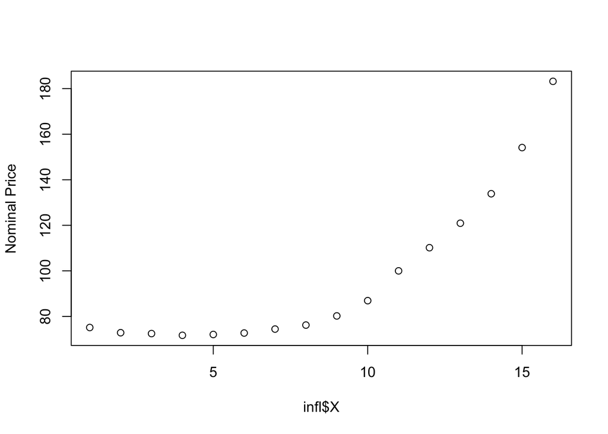

```r
plot(infl$X, infl$val, ylab = 'Nominal Price')
```

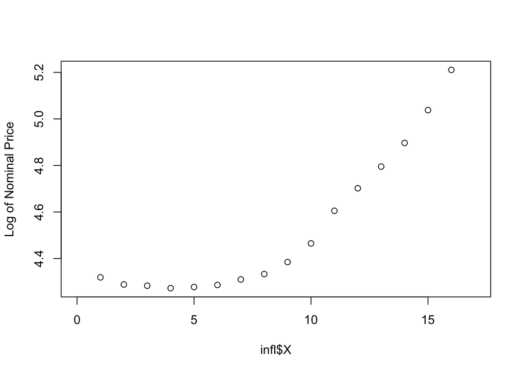

```r
#Well, log did not do much lol
plot(infl$X, log(infl$val), xlim = c(0, 17), ylab = 'Log of Nominal Price')
```

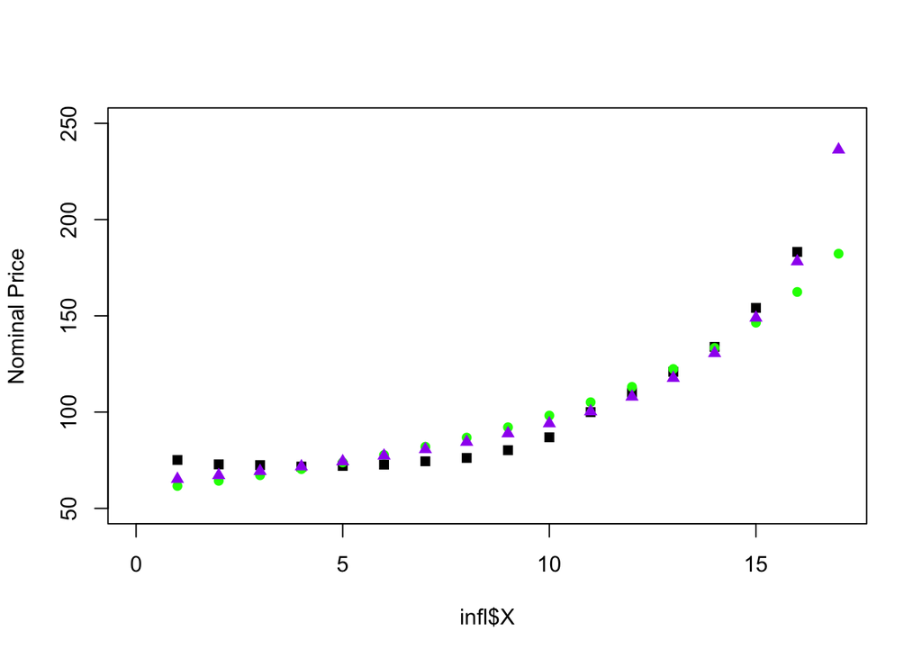

```r
#So as x increases the value increases at an increasing rate. Sounds like a Gamma to me, as alpha grows the expectations grows squaredly so...


infl_mod <- glm(val ~ X, data = infl, family = 'Gamma')
infl_pred <- predict(infl_mod, data.frame(X = 1:17),
                     type = 'response')

plot(infl$X, infl$val, xlim = c(0, 17),
     ylim = c(50, 250), pch = 15, ylab = 'Nominal Price')

#Gamma in Green
points(1:17, infl_pred, col = 'green', pch = 16)


#Inverse Gaussian In Blue
infl_mod2 <- glm(val ~ X, data = infl, family = 'inverse.gaussian')
infl_pred2 <- predict(infl_mod2, data.frame(X = 1:17),
                     type = 'response')
points(1:17, infl_pred2, col = 'purple', pch = 17)
```

```r
#Remember when you look at these graphs we are mostly
#interested in the ratio from one year to the next
```

So I’m still undershooting near the tail end but the inverse gaussian looks solid-ish and the gamma is fair so…

```r
my_infl2 <- infl_pred2[17]/infl_pred2[16]

my_infl <- infl_pred[17]/infl_pred[16]

#Infaltion prediction from gamma
my_infl
```

```
##       17
## 1.122293
```

```r
#Infaltion prediction from the inverse gaussian
my_infl2
```

```
##       17
## 1.325992
```

32% seems unreasonable to me as having been an econ major in undergrad (abondon any investments you have and buy NYC real estate immediately if this was true). 12% is a lot for a single year but more reasonable. So using a design for a first order model over the experimental region [0, .12] we had No Correction Except for KNN, 6% Correction for all observations, and a 12% correction for all observations. This was originally to correct for KNN not being able to train/predict with missing values of Sales Date while still producing the strongest cv when trained without sale date on the whole data than when trained on the complete subset with sales date included.

As such there was a partition in the first run where only some data was scaled for inflation (those without sales date data).

Results were

6% partial = 0.56731

6% full = 0.48533

12% full = 0.51551

Applied to Subrata’s Random Forest estimate we got

Original = 0.40474

6% = 0.38968

8.5% = 0.38597

The 8.5% correction was a last minute thing because we had an extra submission about to expire. Techincally it is not the optimal choice (9% would have been) but it’s what I chose when the clock was ticking down.

As a meta thing we can view this as an estimate of a fixed bias in the SEL of the log of y , that is log(infaltion*y + 1) ~ log(inflation) + log(y) for a large enough y.